# E-commerce Sales Decomposition

## My data

I used quarterly U.S. e-commerce sales, measured in millions of dollars. The data is not seasonally adjusted. Decomposition separates the sales into a trend, a seasonal pattern, and the remaining variation.

```r
library(fpp2)
ECOMNSA <- read.csv("ECOMNSA.csv")
sales <- ts(ECOMNSA$ECOMNSA, start = c(1999, 4), frequency = 4)
head(sales)
```

```
##      Qtr1 Qtr2 Qtr3 Qtr4
## 1999                5225
## 2000 5468 5951 6845 8892
## 2001 7769
```

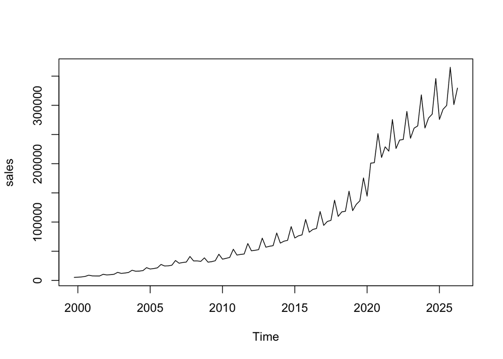

```r
plot(sales)
```

Sales have increased over time. There are also repeating quarterly ups and downs, with larger seasonal swings in recent years.

## STL decomposition

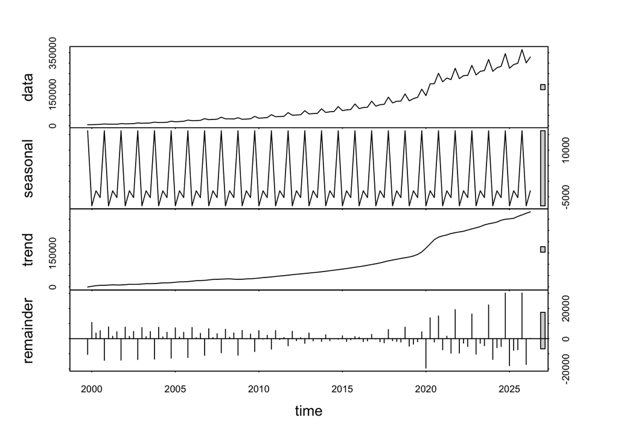

```r
stl_decomp <- stl(sales, s.window = "periodic")
plot(stl_decomp)
```

```r
attributes(stl_decomp)
```

```
## $names
## [1] "time.series" "weights"     "call"        "win"         "deg"
## [6] "jump"        "inner"       "outer"
##
## $class
## [1] "stl"
```

The trend shows the longer-term movement in sales. The seasonal component shows the pattern that repeats each year. The remainder is what is left after removing the trend and seasonality. Using “periodic” keeps the seasonal pattern the same each year.

## Seasonally adjusted sales

```r
seasadj(stl_decomp)
```

```
##            Qtr1       Qtr2       Qtr3       Qtr4
## 1999                                  -10990.594
## 2000  13368.764   9008.413  12102.441  -7323.594
## 2001  15669.764  10696.413  12862.441  -5739.594
## 2002  17294.764  12895.413  15774.441  -2426.594
## 2003  19937.764  15718.413  18841.441   1206.406
## 2004  23608.764  19042.413  22045.441   5623.406
## 2005  27432.764  23417.413  26808.441  11123.406
## 2006  32617.764  28023.413  31297.441  17881.406
## 2007  37360.764  33729.413  36746.441  24798.406
## 2008  41298.764  36472.413  37890.441  22403.406
## 2009  39206.764  35149.413  38975.441  28668.406
## 2010  44288.764  40852.413  44648.441  37199.406
## 2011  51317.764  47597.413  50501.441  46999.406
## 2012  58651.764  54597.413  58031.441  56170.406
## 2013  64801.764  61564.413  64751.441  65039.406
## 2014  71800.764  70254.413  73879.441  75998.406
## 2015  80588.764  79385.413  83274.441  88247.406
## 2016  90472.764  90390.413  94184.441 101902.406
## 2017 102170.764 104059.413 108115.441 121188.406
## 2018 117551.764 120490.413 123698.441 136622.406
## 2019 127429.764 133278.413 141676.441 159342.406
## 2020 152273.764 203956.413 206939.441 235317.406
## 2021 218581.764 231939.413 226699.441 259371.406
## 2022 233940.764 243517.413 246741.441 273277.406
## 2023 251452.764 263955.413 269932.441 301676.406
## 2024 269008.764 281312.413 290052.441 329656.406
## 2025 283615.764 296197.413 304974.441 348944.406
## 2026 309142.764 332587.413
```

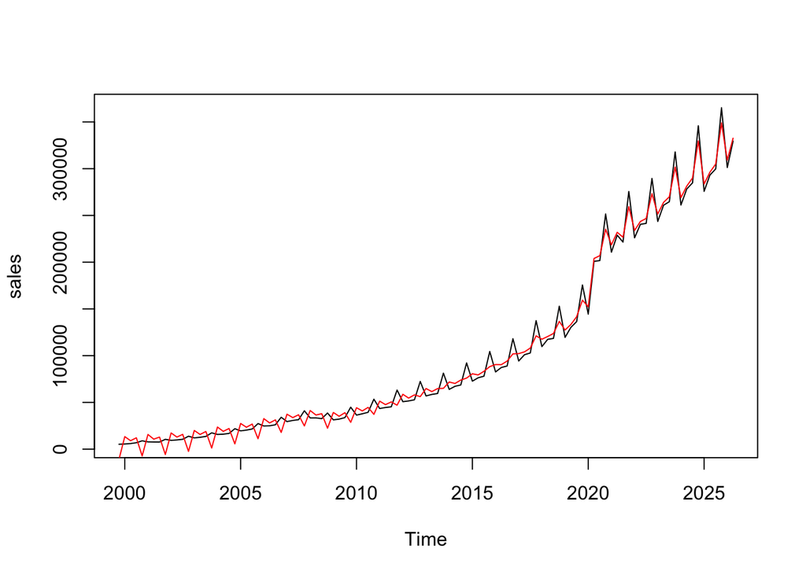

```r
plot(sales)
lines(seasadj(stl_decomp), col = "Red")
```

The black line shows the original sales, and the red line shows sales after removing the estimated seasonal pattern. This helps me see changes beyond the usual quarterly ups and downs.

## Forecast from the decomposition

```r
f_stl <- forecast(stl_decomp, h = 15)
f_stl
```

```
##         Point Forecast    Lo 80    Hi 80    Lo 95    Hi 95
## 2026 Q3       330218.0 313841.2 346594.8 305171.9 355264.1
## 2026 Q4       357034.3 339341.9 374726.8 329976.1 384092.6
## 2027 Q1       338261.3 319086.2 357436.3 308935.6 367587.0
## 2027 Q2       348447.9 327635.5 369260.3 316618.1 380277.7
## 2027 Q3       351591.2 328998.8 374183.6 317039.1 386143.3
## 2027 Q4       378407.5 353903.6 402911.4 340932.0 415883.0
## 2028 Q1       359634.5 333097.6 386171.3 319049.9 400219.1
## 2028 Q2       369821.1 341138.7 398503.5 325955.2 413687.0
## 2028 Q3       372964.4 342031.5 403897.3 325656.6 420272.1
## 2028 Q4       399780.7 366499.0 433062.4 348880.7 450680.7
## 2029 Q1       381007.6 345284.6 416730.7 326373.9 435641.4
## 2029 Q2       391194.3 352942.3 429446.3 332692.9 449695.7
## 2029 Q3       394337.6 353473.3 435201.8 331841.1 456834.1
## 2029 Q4       421153.9 377597.9 464709.9 354540.8 487767.0
## 2030 Q1       402380.8 356057.0 448704.6 331534.7 473227.0
```

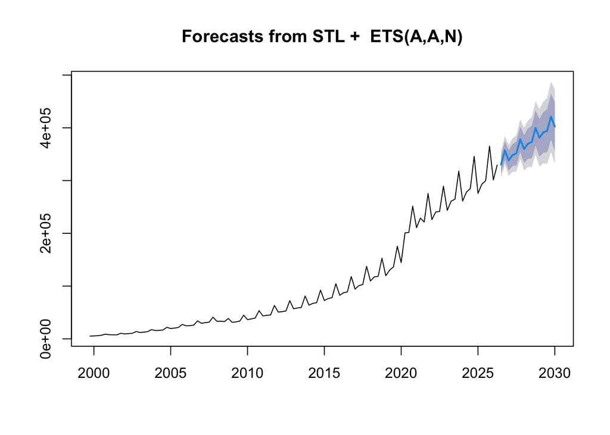

```r
plot(f_stl)
```

Like the lecture example, I forecast 15 periods ahead. For my data, this means 15 quarters. The shaded areas show uncertainty around the predicted sales.

## Classical decomposition

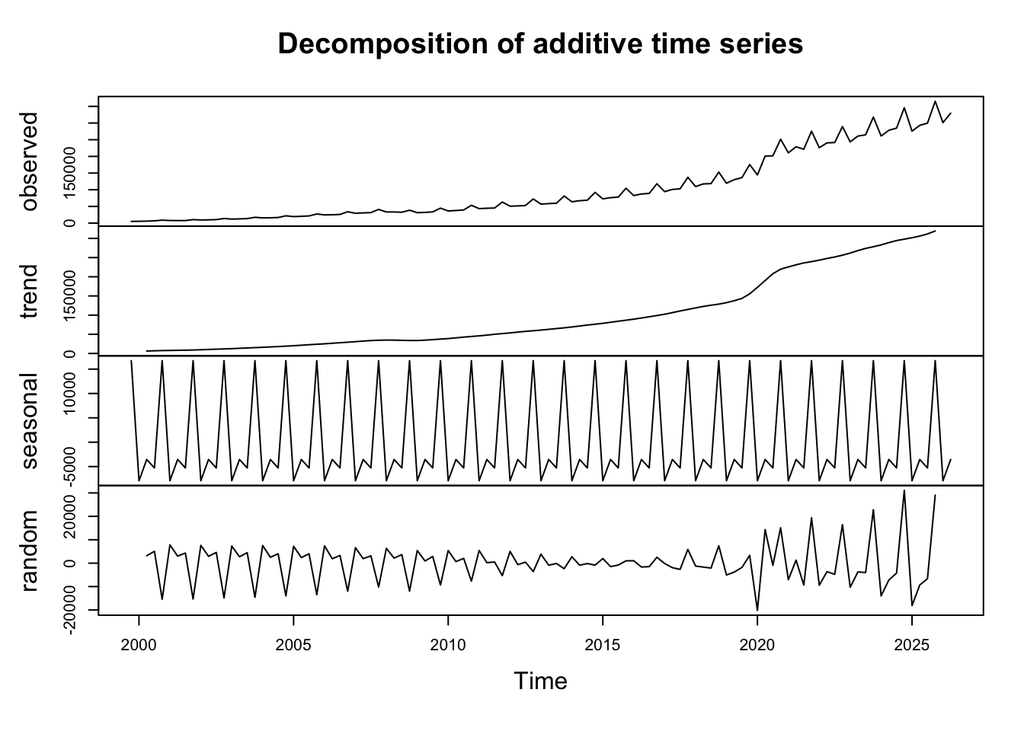

```r
decomp_sales <- decompose(sales)
plot(decomp_sales)
```

```r
attributes(decomp_sales)
```

```
## $names
## [1] "x"        "seasonal" "trend"    "random"   "figure"   "type"
##
## $class
## [1] "decomposed.ts"
```

```r
seasadj(decomp_sales)
```

```
##             Qtr1        Qtr2        Qtr3        Qtr4
## 1999                                     -11513.7689
## 2000  13377.1866   9496.1637  12129.4186  -7846.7689
## 2001  15678.1866  11184.1637  12889.4186  -6262.7689
## 2002  17303.1866  13383.1637  15801.4186  -2949.7689
## 2003  19946.1866  16206.1637  18868.4186    683.2311
## 2004  23617.1866  19530.1637  22072.4186   5100.2311
## 2005  27441.1866  23905.1637  26835.4186  10600.2311
## 2006  32626.1866  28511.1637  31324.4186  17358.2311
## 2007  37369.1866  34217.1637  36773.4186  24275.2311
## 2008  41307.1866  36960.1637  37917.4186  21880.2311
## 2009  39215.1866  35637.1637  39002.4186  28145.2311
## 2010  44297.1866  41340.1637  44675.4186  36676.2311
## 2011  51326.1866  48085.1637  50528.4186  46476.2311
## 2012  58660.1866  55085.1637  58058.4186  55647.2311
## 2013  64810.1866  62052.1637  64778.4186  64516.2311
## 2014  71809.1866  70742.1638  73906.4186  75475.2311
## 2015  80597.1866  79873.1638  83301.4186  87724.2311
## 2016  90481.1866  90878.1638  94211.4186 101379.2311
## 2017 102179.1866 104547.1638 108142.4186 120665.2311
## 2018 117560.1866 120978.1638 123725.4186 136099.2311
## 2019 127438.1866 133766.1638 141703.4186 158819.2311
## 2020 152282.1866 204444.1638 206966.4186 234794.2311
## 2021 218590.1866 232427.1638 226726.4186 258848.2311
## 2022 233949.1866 244005.1638 246768.4186 272754.2311
## 2023 251461.1866 264443.1638 269959.4186 301153.2311
## 2024 269017.1866 281800.1638 290079.4186 329133.2311
## 2025 283624.1866 296685.1638 305001.4186 348421.2311
## 2026 309151.1866 333075.1638
```

This is another way to separate sales into trend, seasonal, and random components. Some trend values at the beginning and end are missing because this method needs observations on both sides to calculate the trend.

## What I learned

E-commerce sales show both long-term growth and a repeating seasonal pattern. I used the additive methods from the lecture example. Because the seasonal swings grow as sales increase, a multiplicative decomposition may be more suitable for this dataset.